# Two-way ANOVA and ANCOVA

You should work through the exercises step-by-step, following the instructions carefully. At various points we will interrupt the flow of instructions with a question. Make a note of your answers so that you can complete the MOLE quiz for this week.

### Limpets and salinity

Limpets live on rocky shores, often in rock pools and on exposed rock surfaces. Those limpets which live in rock pools can experience a very wide range of salinity conditions during the daily tidal cycle, especially if fresh water from inshore flows into the pools when the tide is out. A researcher was interested in whether two different limpet species (*Acmaea scabra* and *Acmaea digitalis*) differ in their internal concentration of sodium ions when exposed to low salinity conditions.

Eight limpets of each species were placed in tanks of water containing (100% sea water; 75% seawater diluted with distilled water, and 50% sea water diluted with distilled water. The data are stored in a file called ACMAEA.CSV. The layout of the data should be fairly obvious: sodium ion concentration is stored in the `Sodium` variable, species codes are in `Species` (levels: ‘scabra’ = *A. scabra*, ‘digitalis’ = *A. digitalis*), and salinity is in `Salinity` (levels: 50, 75 and 100).

Use `glimpse` to explore the structure of the data. Pay close attention to the type of each variable. What kind of variable is `Salinity`?

The `lm` function determines which type of statistical model to fit by looking at the type(s) of the independent variable(s) on the right hand side of the `~` in a formula. These all need to be factors or character vectors in order to fit an ANOVA model. This means if `Salinity` isn’t converted to a factor, `lm` will still fit a model, but it won’t be an ANOVA.

We need to convert `Salinity` to a factor before proceeding. Use the `mutate` function with the `factor` function to convert `Salinity` to a factor variable.

These data can be used to answer the following questions:

1. Does salinity affect the sodium concentration in the limpets?
2. Do the two species differ in their internal sodium concentrations?
3. Do the species differ in their response to changes in salinity?

Prepare an interaction plot to visually assess the likely answers to these questions:

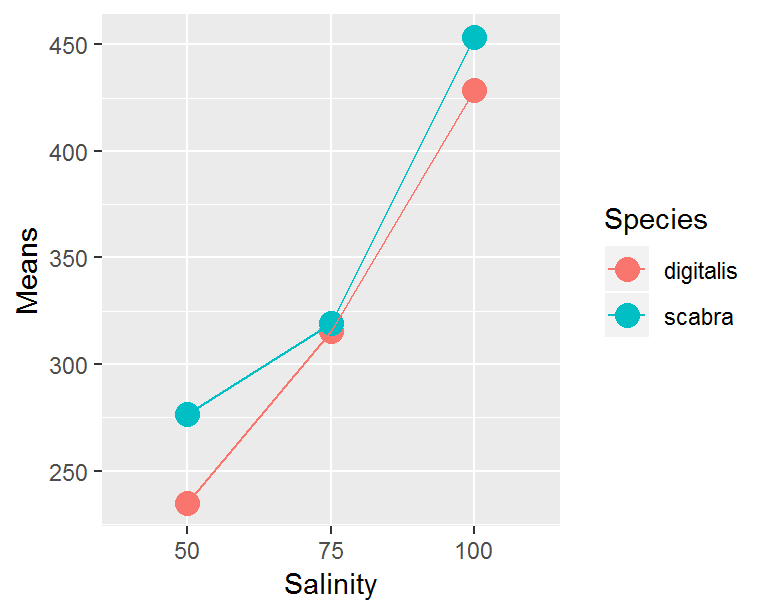

Once you are satisfied that you understand the relationships, fit a statistical model with `lm` that will allow you to address the three questions listed above. Once you have the fitted model object, use this to check the assumptions of your analysis.

**MOLE question**

What type of data are they?

**MOLE question**

Do the data satisfy the assumption of normality?

**MOLE question**

Are the variances similar among treatment combinations?

Next, carry out a statistical analysis to address the three questions above, and decide how to best summarise the results in written form.

**MOLE question**

What effects does the analysis indicate?

| Term | *F* | *d.f.* | *p* |
| --- | --- | --- | --- |
| Salinity effect: | ? | ? | ? |
| Species effect: | ? | ? | ? |
| Interaction: | ? | ? | ? |

**MOLE question**

Summarise the results from the ANOVA in words.

If you find any the global significance tests to be significant, it may be appropriate to carry out one, or more, multiple comparison tests. You should not carry out tests for any effects that are not significant (there’s no point in testing means you already know not to be different!).

**MOLE question**

If there were significant effects in the ANOVA summarise the differences between the means using a table of means with appropriate letter codes, and in words.

**MOLE question**

What does the analysis suggest about the osmoregulation of *Acmaea*.

Finally, see if you can prepare the following “publication quality” plot to summarise the results:

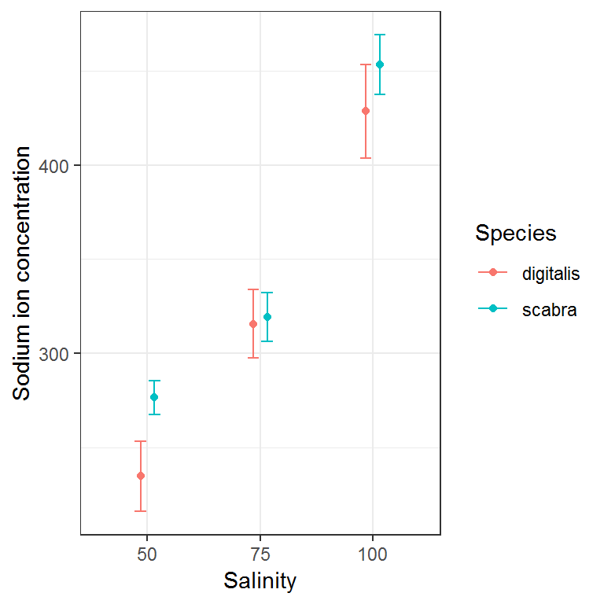

## Density dependence in limpets

Negative density-dependent processes occur when the vital rates of individuals decrease as a function of population density. The strength of density dependent effects often vary with the seasons. Within the intertidal zone, food availability is generally lower in spring than summer, and so we expect that reproduction of intertidal species will lower in spring, compared to summer. However, little is known about the relative strength of density dependence in the two seasons. In order to investigate seasonal density dependent effects, the reproductive performance of the ‘false limpet’ *Siphonaria diemenensis* (a sea snail) was investigated by manipulating population density in spring and summer.

In each season, density was manipulated within 15x15cm enclosures to generate local density treatments of 8, 15, 30 and 50 individuals per enclosure. Enclosures were chosen by randomly positioning enclosures on a 500 meters stretch of coastline. Each density treatment was replicated three times. Mean per capita egg production was estimated over the course of one week to assess reproductive performance. The data are stored in a file called LIMPETS.CSV. The layout of the data should be fairly obvious: egg production is stored in the Eggs variable, season codes are in Season (levels: ‘spring’ and ‘summer’), and density is in Density (levels: 8, 15, 30 and 50).

**MOLE question**

Evaluate the following assumptions: Are the residuals likely to be independent?

Are the numeric variables measured on an appropriate scale?

The values of the independent numeric variable are determined with negligible error?

Construct a scatter plot showing the relationship between egg production and density, highlighting the data for each season in a different colour. Do you think you are likely to find a significant interaction?

**MOLE question** Evaluate the remaining assumptions:

Do the data conform to the linearity assumption?

Are the residuals are drawn from a normal distribution and is their variance constant?

If you are happy with the data proceed with the ANCOVA.

**MOLE question** Summarise the results from the ANCOVA in words. Include a clear statement about the seasonal effect of density dependence.

Finally, produce a publication quality figure to help you summarise your analysis.